# PROYECTO R 2019

CAMILLA MOSSEDDU

16/11/2019

# Sección 1 Expresiones regulares

Las expresiones regulares son una secuencia de caracteres que conforma un patrón de búsqueda. Permiten filtrar textos y encontrar coincidencias. Además se utilizan para validar datos, como por ejemplo fechas, documentos de identidad o contraseñas. Se utilizan también para reemplazar un texto con unas determinadas características concretas por otro.

Actualmente muchos lenguajes de programación cuentan con el soporte necesario para el uso de estas expresiones regulares.

Estos characters pueden ser:

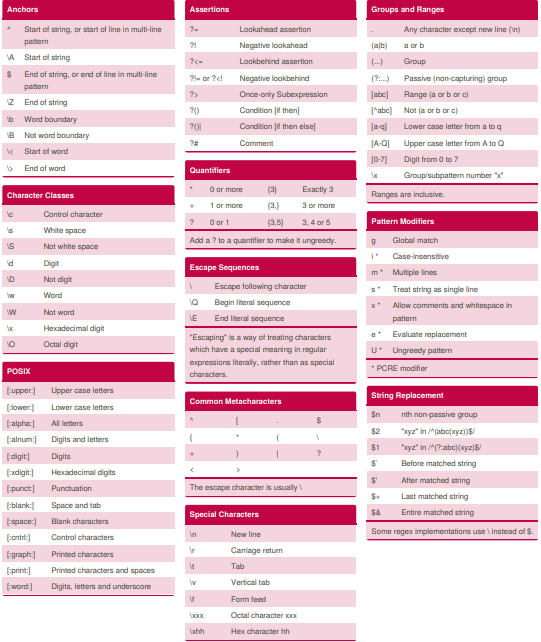

Regex Cheatsheet

# Sección 2 Markdown

Markdown es un lenguaje de marcado que facilita la aplicación de formato a u texto, empleando unos caracteres (como marcas) de una forma especial. Entre dichos caracteres existen cabeceras, listas, links, imágenes, tablas, videos, etc. La intención de Markdown es facilitar el uso de un simple texto plano que pueda ser convertido en un (X)HTML valido. Es decir, que el usuario escriba mas rápido y obtenga un resultado final mejor.

Algunos de los comandos que se utilizan son los siguientes:

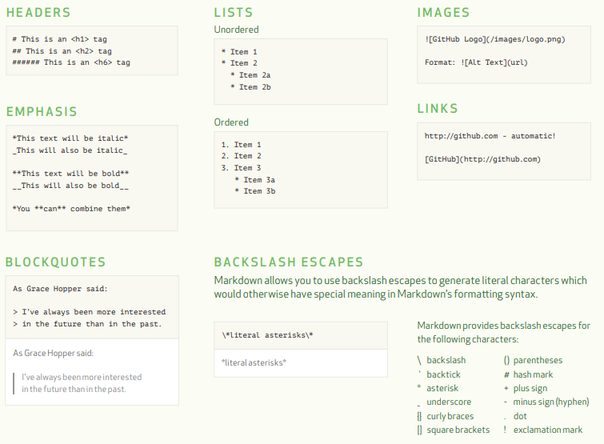

Markdown Cheatsheet

Existen algunos editores de Markdown que se recomienda usar como: Typora, iA Writer, Visual Studio Code, etc.

# Sección 3

Una sección en la que se carguen, estudien, representen gráficamente unos datos de tu elección. No se trata de hacer un análisis estadístico (está fuera de alcance) pero sí un estudio descriptivo mínimo de los aspectos más relevantes de los datos. Este estudio tiene que contener, al menos: * Un gráfico generado con `ggplot2`. * Una tabla.

En primer lugar, nosotros hemos utilizado la técnica de Web Scraping para obtener los datos de milanuncios, concretamente los datos de coches.

Entre los datos concretos de coches, nosotros hemos seleccionado el precio, los kilómetros de uso que tienen, el año del modelo, el tipo de combustible que utilizan, la cilindrada y el número de puertas.

En este caso, ha sido necesario realizar un tratamiento a los datos. En primer lugar, hemos tenido que eliminar las unidades (año, kms, puertas,etc) de las columnas, puesto que no se ha podido modificar mediante la selección de nodos de Web Scrapping.

En Milanuncios, se dibujaba el tipo de combustible en dos elementos distintos (gasolina y diésel), por tanto, a la hora de obtener dicha información, se creaban dos columnas. Por tanto, hemos tenido que combinar dicha información en una única columna (llamada combustible).

Una vez eliminados las unidades y habiendo combinado las columnas, hemos exportado los datos en un fichero llamado Coches.csv.

A continuación se muestran algunos de los datos ya limpios.

```
## # A tibble: 6 x 6
##   precio_data kms_data ano_data cc_data puertas_data combustible
##         <dbl>    <dbl>    <dbl>   <dbl>        <dbl> <chr>
## 1        11.0     210      2013     116            5 diesel
## 2        15.9     140.     2011     250            3 gasolina
## 3         2.6     164      2002     100            3 gasolina
## 4        16.8     145      2013     184            5 diesel
## 5        17       172      2014     136            5 diesel
## 6        12.5     178      2008     204            2 diesel
```

Una vez que se tienen los datos limpios (habiendo eliminado aquellos datos que contenían nulos) se puede comenzar a estudiar y analizar los datos mediante gráficos.

Vemos que no existe una relación detectable a simple vista entre el precio y el número de kilómetros.

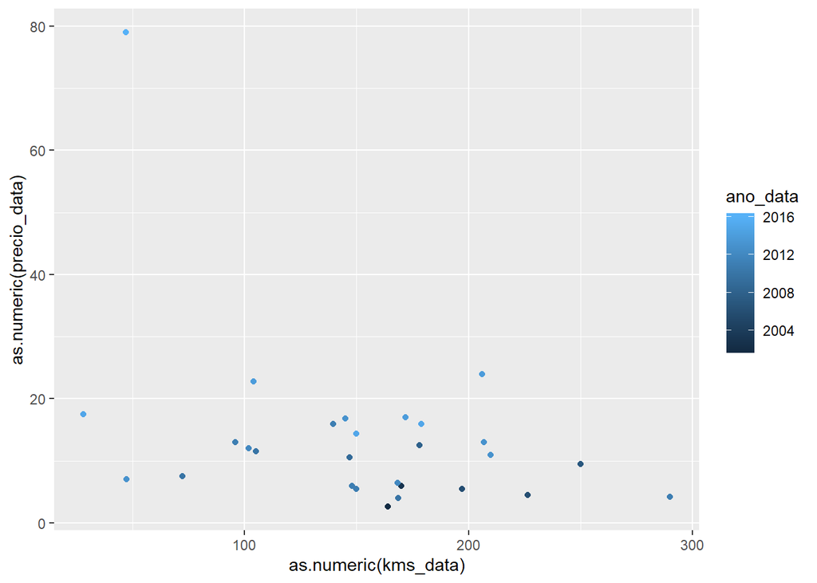

## Hacemos un plot del número de coches por año de versión.

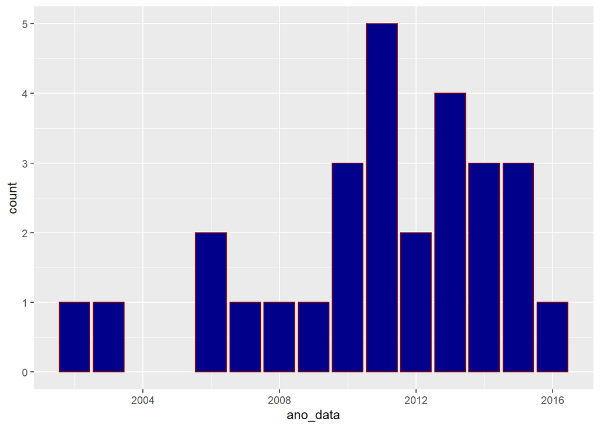

## Hacemos un plot de facetas

Se ha hecho un plot por facetas, utilizando el precio, el combustible y el número de puertas de cada vehículo. Vemos que la mayoría de los vehículos son de tipo diésel y tienen 5 puertas.

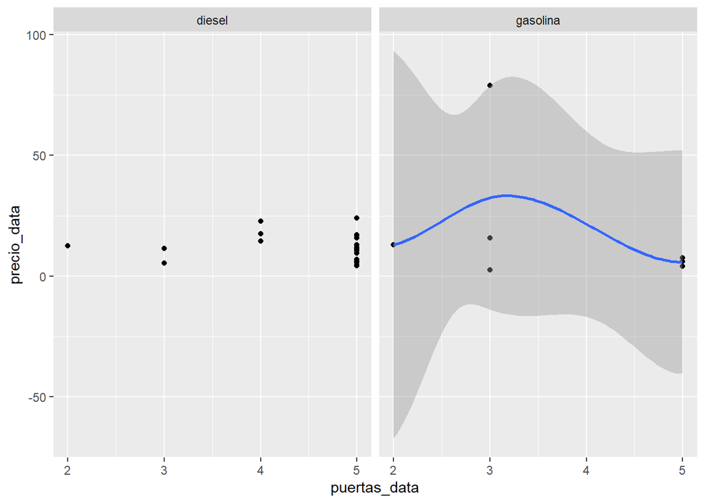

## Hacemos un plot con un tema distinto

Como se puede observar, vemos que existe una relación lineal entre el precio y los caballos. Como cabe esperar, cuanto mayor sea la potencia de un coche, mayor será su precio.

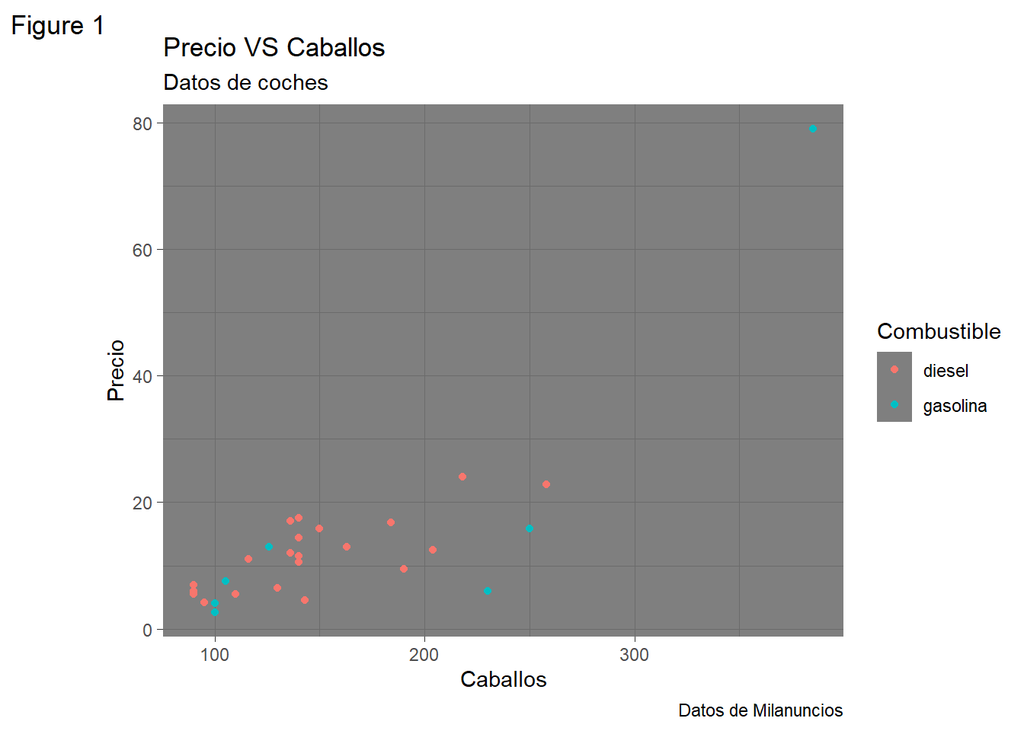

## Usamos el paquete EXPSS para crear tablas

### Tabla sobre los precios y las puertas de los coches

|  | coches_df$puertas_data 2 | coches_df$puertas_data 3 | coches_df$puertas_data 4 | coches_df$puertas_data 5 |
| --- | --- | --- | --- | --- |
| coches_df$precio_data |  |  |  |  |
| 2.6 |  | 1 |  |  |
| 3.999 |  |  |  | 1 |
| 4.2 |  |  |  | 1 |
| 4.499 |  |  |  | 1 |
| 5.49 |  | 1 |  |  |
| 5.5 |  |  |  | 1 |
| 5.999 |  |  |  | 1 |
| 6 |  |  |  | 1 |
| 6.499 |  |  |  | 1 |
| 6.999 |  |  |  | 1 |
| 7.499 |  |  |  | 1 |
| 9.5 |  |  |  | 1 |
| 10.6 |  |  |  | 1 |
| 10.99 |  |  |  | 1 |
| 11.49 |  | 1 |  |  |
| 11.99 |  |  |  | 1 |
| 12.5 | 1 |  |  |  |
| 12.99 | 1 |  |  | 1 |
| 14.4 |  |  | 1 |  |
| 15.9 |  | 1 |  | 1 |
| 16.8 |  |  |  | 1 |
| 17 |  |  |  | 1 |
| 17.5 |  |  | 1 |  |
| 22.79 |  |  | 1 |  |
| 24 |  |  |  | 1 |
| 79 |  | 1 |  |  |
| #Total cases | 2 | 5 | 3 | 18 |

### Tabla sobre los vehiculos en distintos años, su combustible y el numero de puertas

|  | #Total | diesel | gasolina | 2 | 3 | 4 | 5 |
| --- | --- | --- | --- | --- | --- | --- | --- |
| coches_df$ano_data |  |  |  |  |  |  |  |
| 2002 | 3.6 |  | 14.3 |  | 20 |  |  |
| 2003 | 3.6 |  | 14.3 |  |  |  | 5.6 |
| 2006 | 7.1 | 9.5 |  |  | 20 |  | 5.6 |
| 2007 | 3.6 | 4.8 |  |  |  |  | 5.6 |
| 2008 | 3.6 | 4.8 |  | 50 |  |  |  |
| 2009 | 3.6 | 4.8 |  |  |  |  | 5.6 |
| 2010 | 10.7 | 4.8 | 28.6 |  | 20 |  | 11.1 |
| 2011 | 17.9 | 14.3 | 28.6 | 50 | 20 |  | 16.7 |
| 2012 | 7.1 | 9.5 |  |  |  |  | 11.1 |
| 2013 | 14.3 | 19 |  |  |  |  | 22.2 |
| 2014 | 10.7 | 14.3 |  |  |  | 33.3 | 11.1 |
| 2015 | 10.7 | 14.3 |  |  |  | 66.7 | 5.6 |
| 2016 | 3.6 |  | 14.3 |  | 20 |  |  |
| #Total cases | 28 | 21 | 7 | 2 | 5 | 3 | 18 |